## Report: act_report

- Create a **250-word-minimum written report** called "act_report.pdf" or "act_report.html" that communicates the insights and displays the visualization(s) produced from your wrangled data. This is to be framed as an external document, like a blog post or magazine article, for example.

# WeRateDogs Twitter Data Visualization

[figure not shown]

```python
from IPython import display
display.Image("images/WeRateDogs.jpg")
```

# DATA Visualization:

This a way of gaining key insights into your data through different graphical representations. Below are the insights gathered in this project.

Insights:

1.Total number of Dogs in the various dog stages

2.The best rated Dog stage

3.The most fovorite Dog stage

4.The correlation between the #1 tweet image prediction and the second #2 tweet image prediction..

### 1.Total number of Dogs in the various dog stages

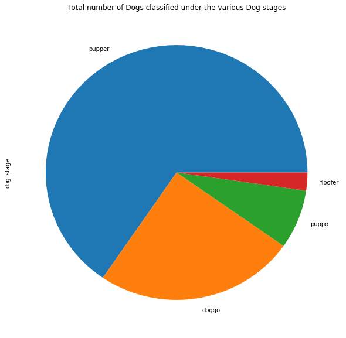

```python
display.Image("images/pie.png")
```

Dogs were classified and rated according to their stages in life and experiences as in Pupper (the youngest), puppo (The older/teenage Dog) and Doggo (the oldest and more experienced).; Others were classified based on dogs with excessive fur as in floofer.

The Pie Chart shows the total number of ratings received by these stages.The Pupper (youngest) Stage recieved the largest number of tweet counts, followed by Doggo (The more experienced and oldest), Puppo (the teenage/older dog), and Floofer (Dogs with excessive Fur).

The means that people mentioned pupper stage more in their tweet followed by Doggo, Puppo and floofer.

### 2.The Best rated dog stage

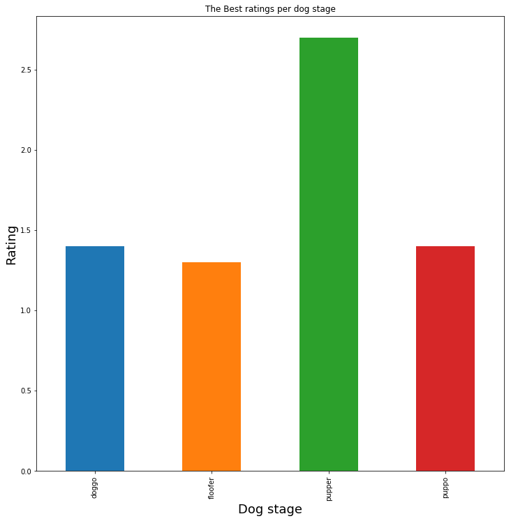

```python
display.Image("images/best.png")
```

We already seen the Dogs rating based on the four stages in which they were classified. Here the Bar Chart shows us the Dogs with the best ratings in each of these four dog stages. A Dog in Pupper stage got the highest rating of about 2.7 rating, followed by two other Dogs with the same rating of 1.4 each, one from Doggo and the other from puppo. The last is another Dog from Floofer stage with rating of 1.3.

### 3. The most favorite Dog stage

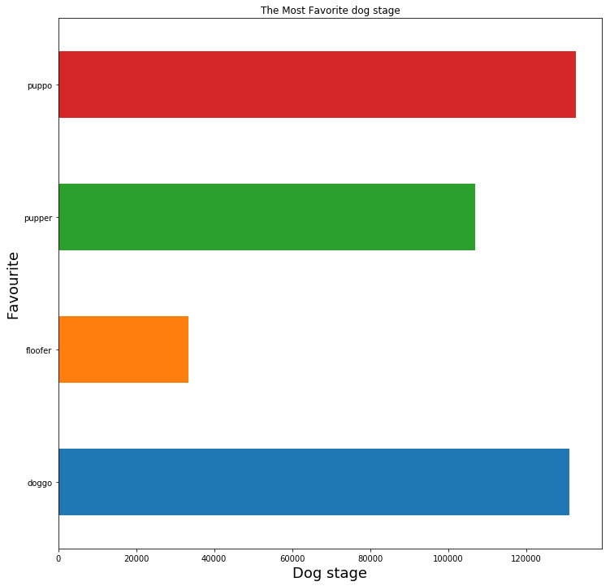

```python
display.Image("images/favorite.png")
```

The Puppo stage Dogs are the most favorite Dogs as the have the largest favorite counts, followed by the Doggo, Pupper and Floofer. This means that people prefers the Puppo stage Dogs to every other Dog stages.

### 4. The correlation between the #1 tweet image prediction and the second #2 tweet image prediction

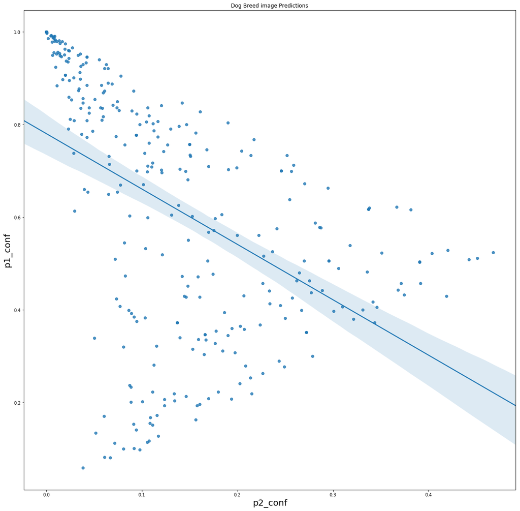

```python
display.Image("images/correlation.png")
```

The Chart above Shows the correlation between first and second algorithms used to predict if an images tweeted belongs to a paricular Dog's breed or not. The confident level (the level at which we are rest assured that the image is a dog breed)for the first algorithm is 95% while the confident level for the second is 1%.

The chart above shows a negative correlation between the two algorithms. As first algorithm tends to its confident level of 95%, the second algorithm moves away from itsconfidence level of 1%. And as the second algorithm approaches its confident level the first moves away from its confident level.

This means that the more you agreed with the first algorithm that this image is likely going to be a Dog breed image, the more another person using the second the algorithm disagrees that the same image is likely not going to be a Dog breed image.